# MATH 324 Final Project

Amy Cao, Amy Folkestad, Anker Hojgaard and Jaxson Stathis

# 1. Project Description

Gold Mine Resorts is looking to understand the predictors for guests who cancel their reservations.The industry average for cancellation rates is twenty percent; however Gold Mine Resorts experienced a 32.8% cancellation rate for reservations between 2015 and 2018. Cancelled reservations represent a total of $4.3 million dollars in lost revenue for this time frame.

*Description of the dataset*

The dataset includes 36,285 rows of booking data, spanning the course of four years (2015-2018). Data collected includes the group size (adult and children), the stay length (count of weekend and weeknight stays), guest upgrades (parking, meal plans, room types and count of special requests), booking details (price and reservation method), the date of stay, year, and status (whether or not the guest cancelled the reservation).

Our team observed there was only one row of data for year 2015 and 2016. We additionally noticed there only 5 data points for meal plan 3. The variables: GroupSize, StayLength, HasChildren, HasRequests and Online were created from the existing dataset. GroupSize was an aggregation of count of adults and children, StayLength was an aggregation of Weekend and Weeknights. HasChildren, HasRequests and Online created binary, true/false (0 and 1) variables from the count of children, requests and instances where the market was online.

The status column (cancelled verses not cancelled), is the response variable of interest in this analysis.

*Goal of study*

The goal of this analysis is to understand the best predictors for guest cancellations in order to develop company policy in response to predicted cancellations.

## 1.1 Research Objectives

**Objective 1:**

The first objective will explore and define the most important numeric variable to predict the percentage that a group will cancel their reservation.

**Objective 2:**

The second objective will explore and define the most important category type variable for predicting the percentage chance a group will cancel their reservation.

**Objective 3:**

The final goal of our statistical analysis will combine our understanding of numeric and category type variables in order to create a statistical model to predict the percent chance that a customer will cancel.

## 1.2 Variables

*Table of variable names and types*

| Variable | Description of Variable | Variable Type |
| --- | --- | --- |
| Status | Cancellation status of booking | C |
| Meal | Type of meal plan selected | C |
| Parking | Parking option selection | C |
| RoomType | Type of room booked | C |
| Market | Market segment of booking | C |
| Month | Month of booking date | C |
| HasChildren | Indicator for children as guests | C |
| HasRequests | Indicator for special requests | C |
| Online | Indicator for an online booking | C |
| Requests | Number of special requests made | Q |
| Adults | Number of adults in the booking | Q |
| Children | Number of children in the booking | Q |
| GroupSize | Number of people in the group | Q |
| StayLength | Total length of stay (nights) | Q |
| Weekends | Number of weekend nights stayed | Q |
| Weeknights | Number of weeknights stayed | Q |
| LeadTime | Num. of days bw booking & arrival | Q |
| AvgPrice | Avg. room price (week of booking) | Q |
| Year | Year of the reservation | Q |

# 2. Detailed Exploratory Data Analysis (EDA)

### Quantitative EDA

For our quantitative exploration we used side by side box plots for every variable to status. Looking at the side by side box plot, the lead time seems to have the largest mean variation when looking at a difference in status. This indicates it might be the best predictor for predicting cancellation rates. Conversely the variables: GroupSize, StayLength, AvgPrice, Adults, and Children do not seem to be strong individual predictors for cancellation rates.

Quantitative Explanatory Variables

| Status | Mean_LeadTime | Mean_AvgPrice | Mean_GroupSize | Mean_StayLength |
| --- | --- | --- | --- | --- |
| Canceled | 139.220 | 110.580 | 2.034 | 3.280 |
| Not_Canceled | 58.934 | 99.933 | 1.909 | 2.886 |

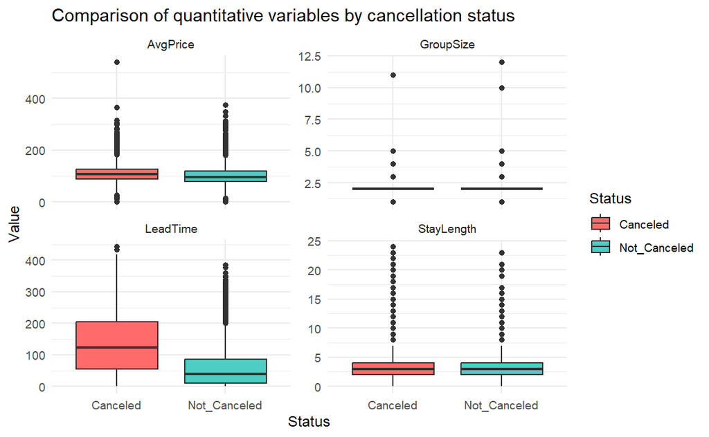

Quantitative Explanatory Variables Table 2

[output not shown]

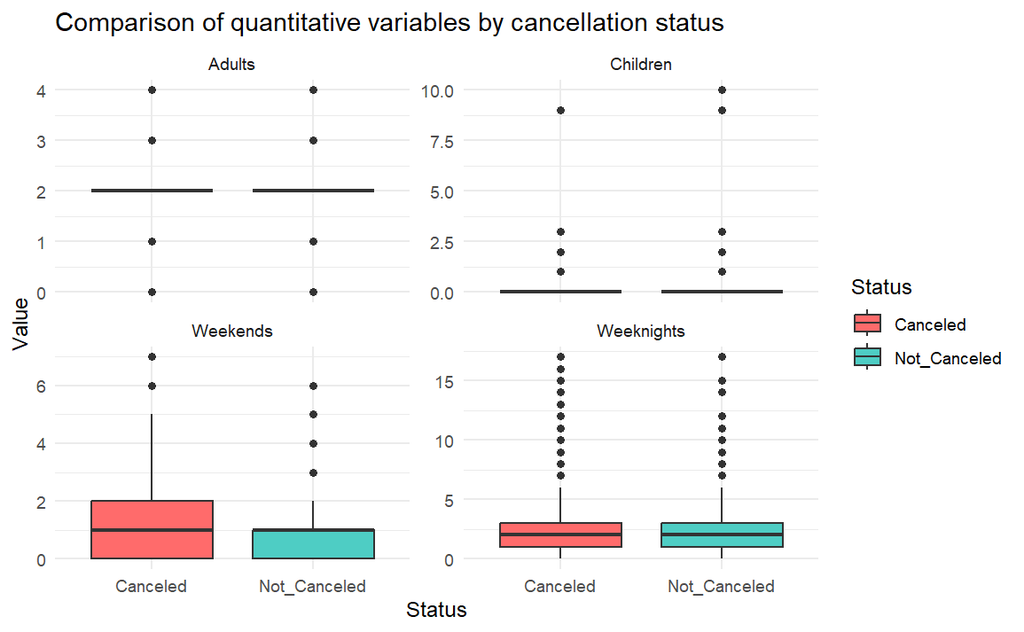

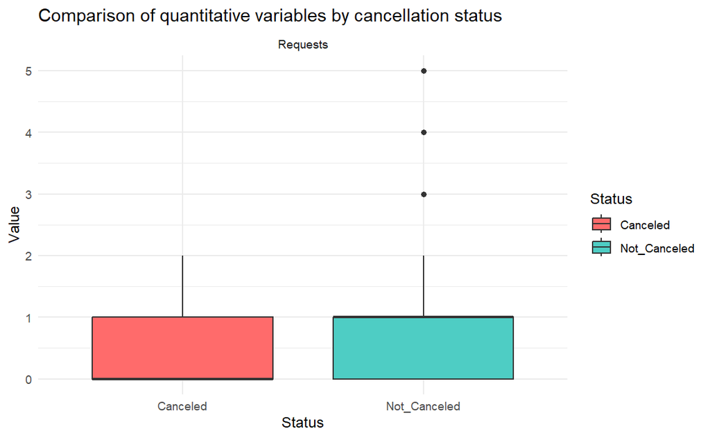

### Categorical EDA

For our categorical exploration, we investigated: RoomType, Meal, Market, Month, HasRequest, Online (new variable where Market = Online), or if the group had children. Looking at the side by side bar plots we have found the variables: HasRequests, Month, Market, and Online to all be individual indicators of cancellation rates. Looking at the visualizations, the best indicators appear to be: HasRequests, Month, and Market. Other important observations include the very low count for many of the room types, low counts of meal plan three, and low counts for the Aviation market type. These limited data points might be an issue if using these categories to create a model, as they might not be sufficient to cover the conditions.

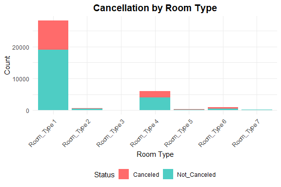

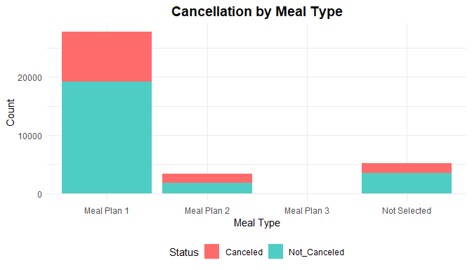

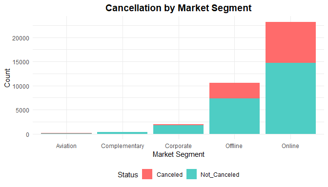

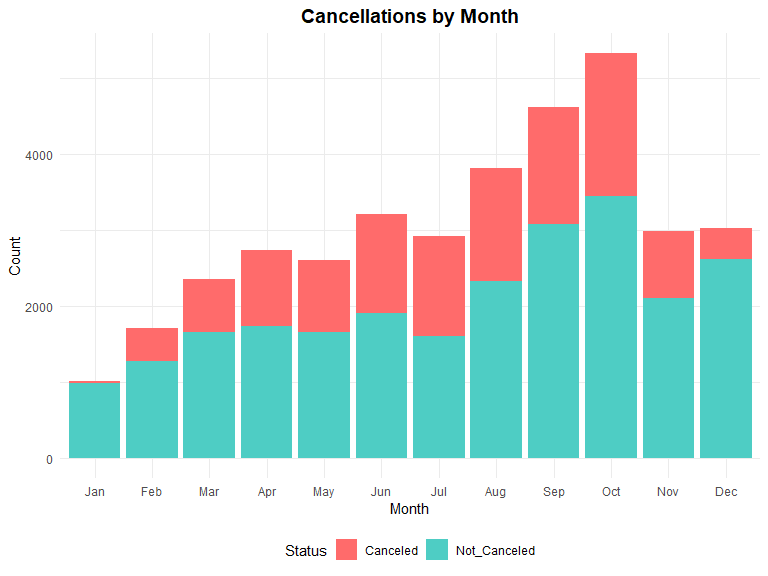

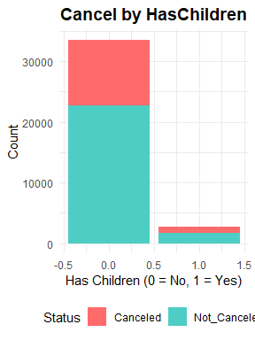

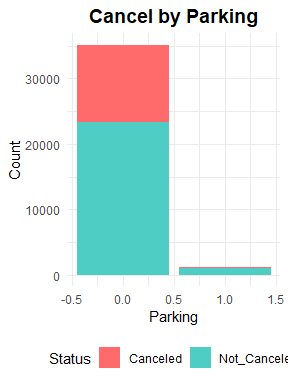

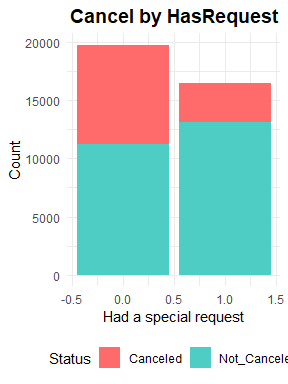

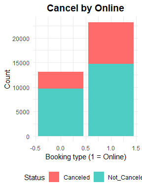

# 3. Statistical Analysis

## 3.1 Objective 1

The metrics used to determine the best quantitative predictor were AIC and residual deviance. All of the individual models created from each variable were statistically significant, with most having a p-value less than 2*10^-16. However, the AIC and residual deviance for the generalized linear model predicting Status with LeadTime was significantly lower than the models for AvgPrice, StayLength, GroupSize, Children, Adults, Weeknights, Weekdays, and Requests, showing that LeadTime is the greatest individual quantitative predictor for Status. Additional the AIC for Groupsize was lower than both individual models for Children and Adults. In the same way, StayLength was a better indicator than Weekends or Weekdays.

For the conditions of the model using LeadTime, there is slight concern about the equal variance condition. Due to slight flaring of the logit plot, we attempted a variety of transformations (square root, logarithmic, inverse), but this had almost no impact on the conditions and made the model unnecessarily complicated. Additionally there were issues of equal variance for all the quantitative variables. After this analysis, we decided that LeadTime is the best individual quantitative predictor for status.

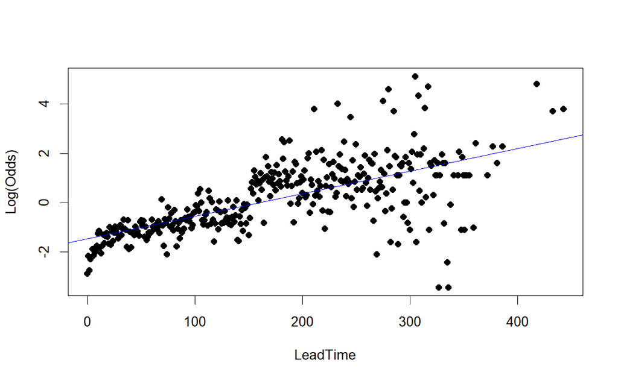

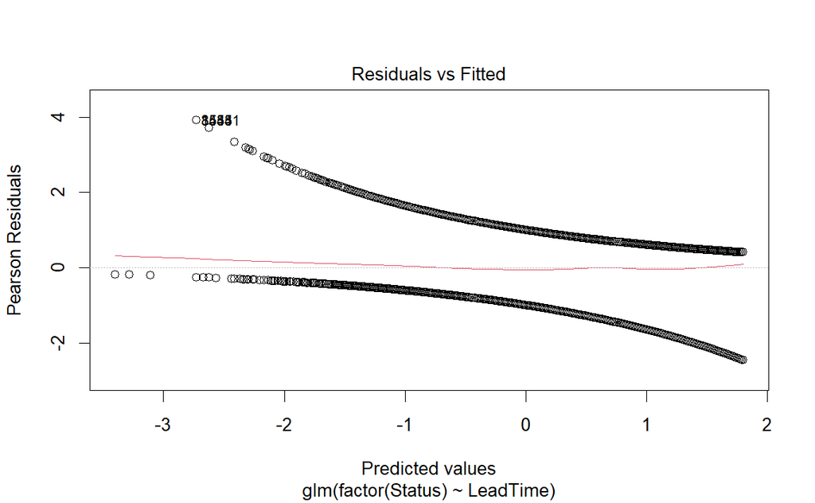

# Quantitative Model

LeadTime has a a p-value of less than $2*10^{-16}$, we have strong evidence that LeadTime is a statistically significant predictor for cancellation rates.

**Logit function for Status using LeadTime:**

$$\widehat{log(\frac{\pi}{1-\pi})} =
1.8046260 - 0.0117484(LeadTime)$$

**Odds for Status using LeadTime:**

$$odds(Status) = e^{1.8046260 -
0.0117484(LeadTime)}$$

$$odds \space ratio = e^{\widehat \beta_1}
= e^{-0.0117484} = 0.988324$$

**Probability function for Status using LeadTime:**

$$p(Status) = \widehat \pi =
\frac{e^{1.8046260 - 0.0117484(LeadTime)}}{1-e^{1.8046260 -
0.0117484(LeadTime)}}$$

[figure not shown]

## 3.2 Objective 2

Looking at the AIC for the categorical models, HasRequests was shown to be the best single categorical explanatory variable for predicting cancellations. This is within the expectations of our exploratory data analysis, as it was also followed by Month and Market.

The conditions for our model are met because we have many instances for guests making requests and guests not making requests, as indicated by our “Has Requests” table in the appendix.

**Logit function for Status using HasRequests:**

$$\widehat{log(\frac{\pi}{1-\pi})} =
0.27328 + 1.09756(HasRequests)$$

**Probability function for Status using HasRequests:**

$$p(Status) = \widehat \pi =
\frac{e^{0.27328 + 1.09756(HasRequests)}}{1-e^{0.27328 +
1.09756(HasRequests)}}$$
**odds for Status using HasRequests:**

$$odds(Status) = e^{0.27328 +
1.09756(HasRequests)}$$

$$odds \space ratio = e^{\widehat \beta_1}
= e^{1.09756} = 2.996845$$

HasRequests is a binary categorical variable. When HasRequests = 1 (at least special request was made), the predicted odds of not cancelling are approximately 3 times higher than when HasRequests = 0 (no special requests were made).

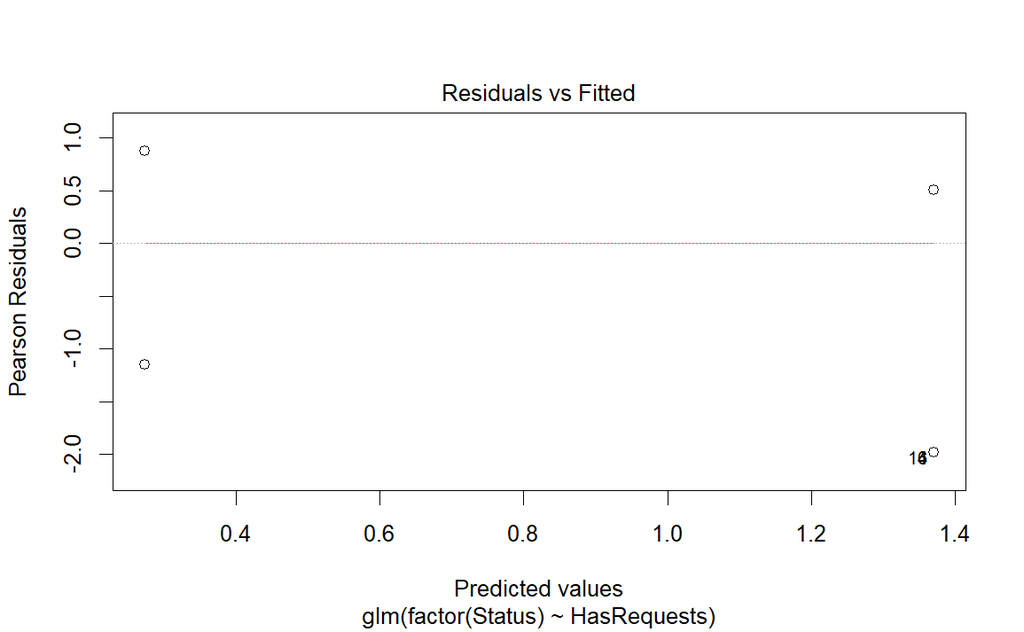

## 3.3 Objective 3

When observing the ANOVA table, the HasChildren variable was not statistically significant. We replaced the HasChildren variable with the Children variable and observed a large p value for this created indicator column as well (greater than .2 in both instances). We additionally removed Year from the statistical model, since this historical data point is not useful for future predictions.

Using forward step analysis, the AIC values recommended using all the remaining variables, including LeadTime, HasRequests, Market, Month, AvgPrice, Parking, RoomType, StayLength, Meal and GroupSize. The AIC of this model was 30,674.

We used the output from an ANOVA table to eliminate variables one at a time, starting with GroupSize (the highest p value). The final model we selected used LeadTime, Market, Requests, Month, AvgPrice, and StayLength. While our AIC increased slightly to 31,109, we reduced the variable count from 10 to 6. Simplifying the model to six variables is far easier to utilize for improvements to Gold Mine Resorts marketing procedures, and only changed the AIC value by 1.4%. Additionally, our model had good variance and normality, in addition to fitting closely to the expected results (as indicated by the empirical logit plot).

**Cross Validation**

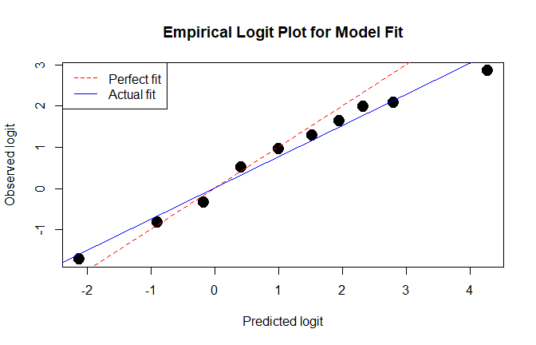

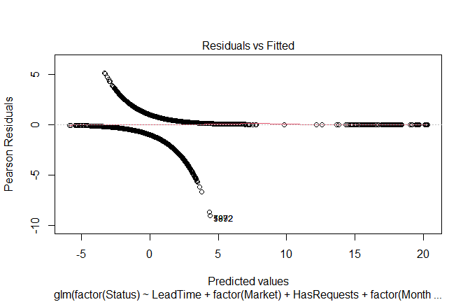

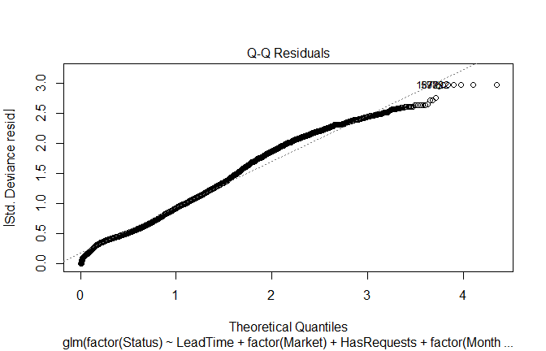

**Key Quantitative Predictors:***

To summarize, the business implication is that longer lead times, higher prices, and longer stays correlate with higher cancellation risk. In addition, LeadTime, AvgPrice, and StayLength have respective p-values of <2e-16, <2e-16, and 7.49e-16, indicating that these variables are useful for predicting cancellation rates.

$$odds \space ratio_{LeadTime} =
e^{-0.0161356} = 0.984$$

For each additional day in lead time, the predicted odds of not cancelling decrease by a factor of 0.984, holding all other variables constant.

$$odds \space ratio_{AvgPrice} =
e^{-0.0145549} = 0.985$$

For each $1 increase in average price, the predicted odds of not cancelling decrease by a factor of 0.985, holding all other variables constant.

$$odds \space ratio_{StayTime} =
e^{-0.0643062} = 0.938$$

For each additional night in the hotel, the predicted odds of not cancelling decrease by a factor of 0.938, holding all other variables constant.

**Key Categorical Predictors:**

$$odds \space ratio_{HasRequests} =
e^{2.0247462} = 7.57$$

Holding all other variables constant, when a guest makes at least one special request the predicted odds of not cancelling are approximately 8 times higher than those without special requests. With a p-value <2e-16, this variable is useful to predict Status.

$$odds \space ratio_{Market(Corporate)} =
e^{1.0866028} = 2.96$$

Holding all other variables constant, when Gold Mine Resorts has a corporate booking the predicted odds of not cancelling are approximately 3 times higher than an aviation booking (baseline). With a p-value of 3.95e-07, this segment is useful in predicting Status.

$$odds \space ratio_{Market(Offline)} =
e^{1.6324226} = 5.12$$

Holding all other variables constant, when Gold Mine Resorts has an offline booking the predicted odds of not cancelling are approximately 5 times higher than an aviation booking (baseline). With a p-value of 8.80e-16, this segment is useful in predicting Status.

$$odds \space ratio_{Market(Online)} =
e^{-0.2199951} = 0.8$$

Holding all other variables constant, when Gold Mine Resorts has an online booking the predicted odds of not cancelling decrease by a factor of 0.8 compared to an aviation booking (baseline). However, with a p-value of 0.27308, this segment is not statistically significant in predicting Status.

$$odds \space ratio_{Month(Feb-Nov)}
\approx e^{-2.28} = 0.102$$

Holding all other variables constant, when there is a booking made in December the predicted odds of not cancelling decrease by a factor of 0.55 when compared to bookings made in January (baseline). December is a statistically significant segment of Month in predicting Status with a p-value of 0.00674.

# 4. Conclusions

**Objective 2:**

When considering only the categories of factors available from the dataset or synthesized, we found that HasRequests is the most useful variable for predicting cancellation rates. If a guest has a reservation request, the predicted of odds of a cancellation decreases by a factor of three.

**Objective 3:**

While this model is a good starting point for predicting hotel cancellations, we noticed that there was a significant increase in total reservations between 2017 and 2018. Further, 2018 had a significant spike in online reservations that led to cancellations. If Gold Mine Resorts has access to further details about the sources for online bookings, this may prove to be a beneficial research study in the future. Other factors impacting the economy between 2017 and 2018 may also be useful for predicting cancellations.

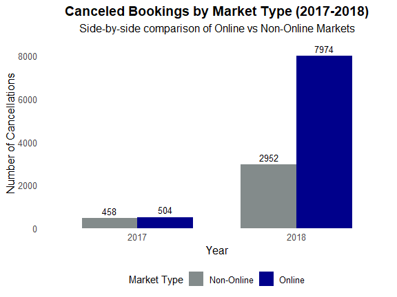

# 5. Appendix

Below are tables used in our exploratory data analysis, followed by the statistical output of our models and cross validation.

**Data Tables**

Room Type

| RoomType | Status | count | proportion |
| --- | --- | --- | --- |
| Room_Type 1 | Canceled | 9076 | 0.323 |
| Room_Type 1 | Not_Canceled | 19062 | 0.677 |
| Room_Type 2 | Canceled | 228 | 0.329 |
| Room_Type 2 | Not_Canceled | 464 | 0.671 |
| Room_Type 3 | Canceled | 2 | 0.286 |
| Room_Type 3 | Not_Canceled | 5 | 0.714 |
| Room_Type 4 | Canceled | 2069 | 0.341 |
| Room_Type 4 | Not_Canceled | 3990 | 0.659 |
| Room_Type 5 | Canceled | 72 | 0.272 |
| Room_Type 5 | Not_Canceled | 193 | 0.728 |
| Room_Type 6 | Canceled | 406 | 0.420 |
| Room_Type 6 | Not_Canceled | 560 | 0.580 |
| Room_Type 7 | Canceled | 36 | 0.228 |
| Room_Type 7 | Not_Canceled | 122 | 0.772 |

Meal Option

| Meal | Status | count | proportion |
| --- | --- | --- | --- |
| Meal Plan 1 | Canceled | 8681 | 0.312 |
| Meal Plan 1 | Not_Canceled | 19161 | 0.688 |
| Meal Plan 2 | Canceled | 1507 | 0.456 |
| Meal Plan 2 | Not_Canceled | 1799 | 0.544 |
| Meal Plan 3 | Canceled | 1 | 0.200 |
| Meal Plan 3 | Not_Canceled | 4 | 0.800 |
| Not Selected | Canceled | 1700 | 0.331 |
| Not Selected | Not_Canceled | 3432 | 0.669 |

Market

| Market | Status | count | proportion |
| --- | --- | --- | --- |
| Aviation | Canceled | 37 | 0.296 |
| Aviation | Not_Canceled | 88 | 0.704 |
| Complementary | Not_Canceled | 391 | 1.000 |
| Corporate | Canceled | 220 | 0.109 |
| Corporate | Not_Canceled | 1797 | 0.891 |
| Offline | Canceled | 3154 | 0.299 |
| Offline | Not_Canceled | 7377 | 0.701 |
| Online | Canceled | 8478 | 0.365 |
| Online | Not_Canceled | 14743 | 0.635 |

Parking

| Parking | Status | count | proportion |
| --- | --- | --- | --- |
| 0 | Canceled | 11775 | 0.335 |
| 0 | Not_Canceled | 23386 | 0.665 |
| 1 | Canceled | 114 | 0.101 |
| 1 | Not_Canceled | 1010 | 0.899 |

Month

| Month | Status | count | proportion |
| --- | --- | --- | --- |
| Jan | Canceled | 24 | 0.024 |
| Jan | Not_Canceled | 990 | 0.976 |
| Feb | Canceled | 431 | 0.253 |
| Feb | Not_Canceled | 1274 | 0.747 |
| Mar | Canceled | 700 | 0.297 |
| Mar | Not_Canceled | 1658 | 0.703 |
| Apr | Canceled | 996 | 0.364 |
| Apr | Not_Canceled | 1741 | 0.636 |
| May | Canceled | 949 | 0.365 |
| May | Not_Canceled | 1650 | 0.635 |
| Jun | Canceled | 1291 | 0.403 |
| Jun | Not_Canceled | 1912 | 0.597 |
| Jul | Canceled | 1314 | 0.450 |
| Jul | Not_Canceled | 1607 | 0.550 |
| Aug | Canceled | 1488 | 0.390 |
| Aug | Not_Canceled | 2325 | 0.610 |
| Sep | Canceled | 1539 | 0.334 |
| Sep | Not_Canceled | 3073 | 0.666 |
| Oct | Canceled | 1880 | 0.353 |
| Oct | Not_Canceled | 3440 | 0.647 |
| Nov | Canceled | 875 | 0.294 |
| Nov | Not_Canceled | 2106 | 0.706 |
| Dec | Canceled | 402 | 0.133 |
| Dec | Not_Canceled | 2620 | 0.867 |

Has Requests

| HasRequests | Status | count | proportion |
| --- | --- | --- | --- |
| 0 | Canceled | 8547 | 0.432 |
| 0 | Not_Canceled | 11233 | 0.568 |
| 1 | Canceled | 3342 | 0.202 |
| 1 | Not_Canceled | 13163 | 0.798 |

Has Children

| HasChildren | Status | count | proportion |
| --- | --- | --- | --- |
| 0 | Canceled | 10885 | 0.324 |
| 0 | Not_Canceled | 22698 | 0.676 |
| 1 | Canceled | 1004 | 0.372 |
| 1 | Not_Canceled | 1698 | 0.628 |

Online Booking

| Online | Status | count | proportion |
| --- | --- | --- | --- |
| 0 | Canceled | 3411 | 0.261 |
| 0 | Not_Canceled | 9653 | 0.739 |
| 1 | Canceled | 8478 | 0.365 |
| 1 | Not_Canceled | 14743 | 0.635 |

Requests

| Requests | Status | count | proportion |
| --- | --- | --- | --- |
| 0 | Canceled | 8547 | 0.432 |
| 0 | Not_Canceled | 11233 | 0.568 |
| 1 | Canceled | 2705 | 0.238 |
| 1 | Not_Canceled | 8674 | 0.762 |
| 2 | Canceled | 637 | 0.146 |
| 2 | Not_Canceled | 3727 | 0.854 |
| 3 | Not_Canceled | 676 | 1.000 |
| 4 | Not_Canceled | 78 | 1.000 |
| 5 | Not_Canceled | 8 | 1.000 |

**Quantitative Variable Models**

```
Call:
glm(formula = factor(Status) ~ AvgPrice, family = binomial(link = "logit"),
    data = hotel_bookings)

Coefficients:
              Estimate Std. Error z value Pr(>|z|)
(Intercept)  1.6315518  0.0365165   44.68   <2e-16 ***
AvgPrice    -0.0086872  0.0003261  -26.64   <2e-16 ***
---
Signif. codes:  0 ‘***’ 0.001 ‘**’ 0.01 ‘*’ 0.05 ‘.’ 0.1 ‘ ’ 1

(Dispersion parameter for binomial family taken to be 1)

    Null deviance: 45901  on 36284  degrees of freedom
Residual deviance: 45167  on 36283  degrees of freedom
AIC: 45171

Number of Fisher Scoring iterations: 4
```

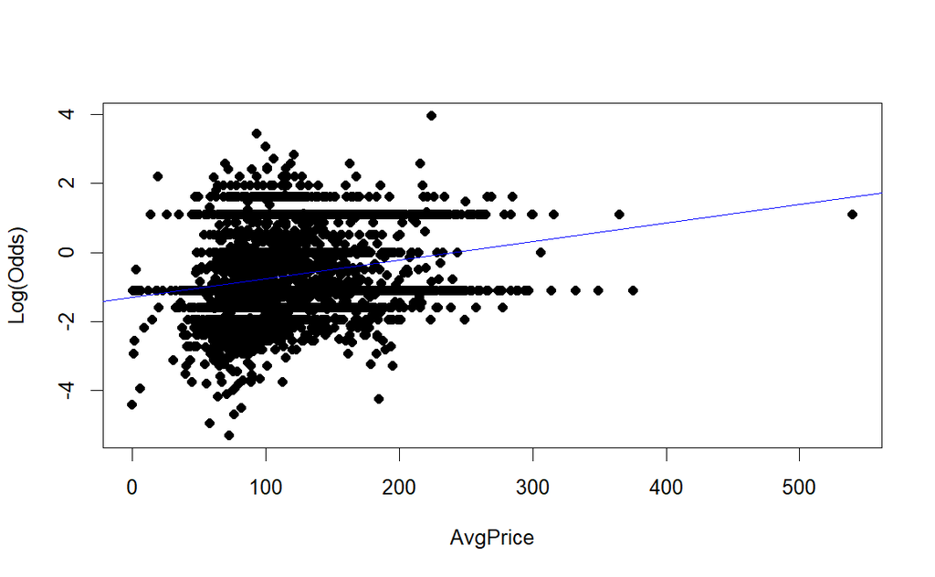

```
Call:
glm(formula = factor(Status) ~ LeadTime, family = binomial(link = "logit"),
    data = hotel_bookings)

Coefficients:
              Estimate Std. Error z value Pr(>|z|)
(Intercept)  1.8046260  0.0194124   92.96   <2e-16 ***
LeadTime    -0.0117484  0.0001593  -73.73   <2e-16 ***
---
Signif. codes:  0 ‘***’ 0.001 ‘**’ 0.01 ‘*’ 0.05 ‘.’ 0.1 ‘ ’ 1

(Dispersion parameter for binomial family taken to be 1)

    Null deviance: 45901  on 36284  degrees of freedom
Residual deviance: 38894  on 36283  degrees of freedom
AIC: 38898

Number of Fisher Scoring iterations: 4
```

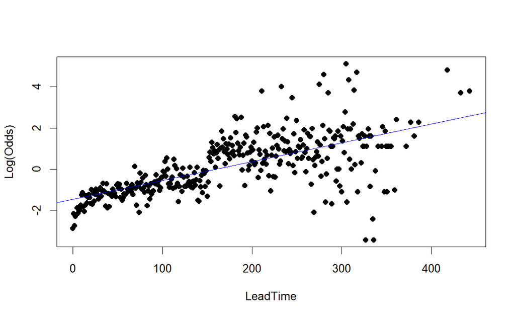

```
Call:
glm(formula = factor(Status) ~ StayLength, family = binomial(link = "logit"),
    data = hotel_bookings)

Coefficients:
             Estimate Std. Error z value Pr(>|z|)
(Intercept)  1.086290   0.022432   48.43   <2e-16 ***
StayLength  -0.119786   0.006249  -19.17   <2e-16 ***
---
Signif. codes:  0 ‘***’ 0.001 ‘**’ 0.01 ‘*’ 0.05 ‘.’ 0.1 ‘ ’ 1

(Dispersion parameter for binomial family taken to be 1)

    Null deviance: 45901  on 36284  degrees of freedom
Residual deviance: 45524  on 36283  degrees of freedom
AIC: 45528

Number of Fisher Scoring iterations: 4
```

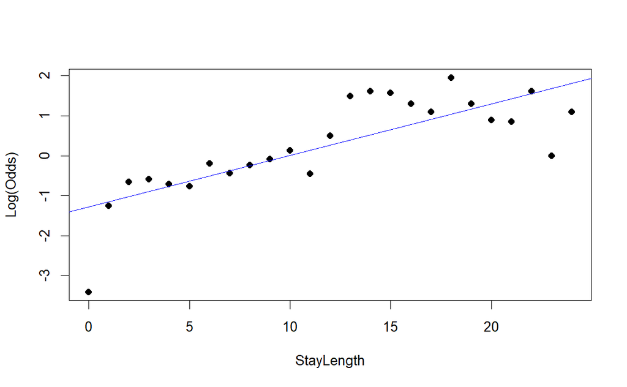

```
Call:
glm(formula = factor(Status) ~ GroupSize, family = binomial(link = "logit"),
    data = hotel_bookings)

Coefficients:
            Estimate Std. Error z value Pr(>|z|)
(Intercept)  1.29287    0.03602   35.89   <2e-16 ***
GroupSize   -0.29141    0.01721  -16.93   <2e-16 ***
---
Signif. codes:  0 ‘***’ 0.001 ‘**’ 0.01 ‘*’ 0.05 ‘.’ 0.1 ‘ ’ 1

(Dispersion parameter for binomial family taken to be 1)

    Null deviance: 45901  on 36284  degrees of freedom
Residual deviance: 45612  on 36283  degrees of freedom
AIC: 45616

Number of Fisher Scoring iterations: 4
```

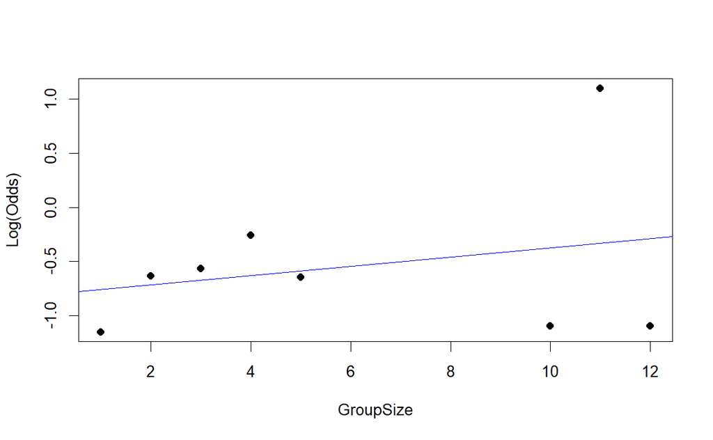

```
Call:
glm(formula = factor(Status) ~ Adults, family = binomial(link = "logit"),
    data = hotel_bookings)

Coefficients:
            Estimate Std. Error z value Pr(>|z|)
(Intercept)  1.39588    0.04303   32.44   <2e-16 ***
Adults      -0.36366    0.02211  -16.45   <2e-16 ***
---
Signif. codes:  0 ‘***’ 0.001 ‘**’ 0.01 ‘*’ 0.05 ‘.’ 0.1 ‘ ’ 1

(Dispersion parameter for binomial family taken to be 1)

    Null deviance: 45901  on 36284  degrees of freedom
Residual deviance: 45624  on 36283  degrees of freedom
AIC: 45628

Number of Fisher Scoring iterations: 4
```

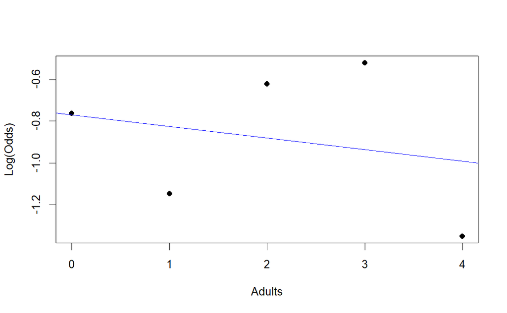

```
Call:
glm(formula = factor(Status) ~ Children, family = binomial(link = "logit"),
    data = hotel_bookings)

Coefficients:
            Estimate Std. Error z value Pr(>|z|)
(Intercept)  0.73716    0.01160  63.573  < 2e-16 ***
Children    -0.16764    0.02686  -6.241 4.34e-10 ***
---
Signif. codes:  0 ‘***’ 0.001 ‘**’ 0.01 ‘*’ 0.05 ‘.’ 0.1 ‘ ’ 1

(Dispersion parameter for binomial family taken to be 1)

    Null deviance: 45901  on 36284  degrees of freedom
Residual deviance: 45863  on 36283  degrees of freedom
AIC: 45867

Number of Fisher Scoring iterations: 4
```

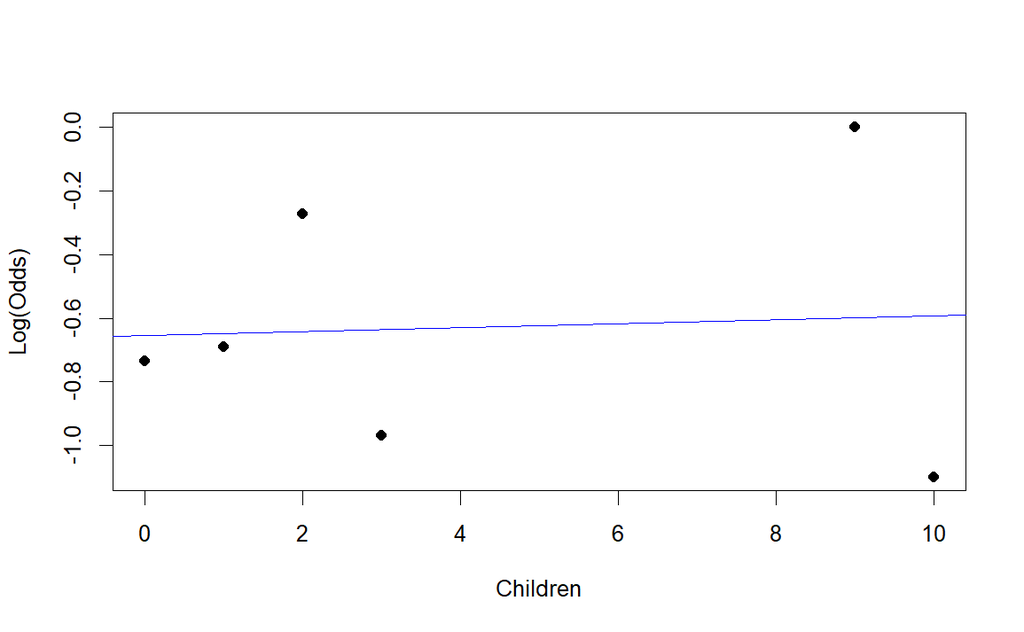

```
Call:
glm(formula = factor(Status) ~ Weekends, family = binomial(link = "logit"),
    data = hotel_bookings)

Coefficients:
            Estimate Std. Error z value Pr(>|z|)
(Intercept)  0.84213    0.01555   54.15   <2e-16 ***
Weekends    -0.14869    0.01272  -11.69   <2e-16 ***
---
Signif. codes:  0 ‘***’ 0.001 ‘**’ 0.01 ‘*’ 0.05 ‘.’ 0.1 ‘ ’ 1

(Dispersion parameter for binomial family taken to be 1)

    Null deviance: 45901  on 36284  degrees of freedom
Residual deviance: 45765  on 36283  degrees of freedom
AIC: 45769

Number of Fisher Scoring iterations: 4
```

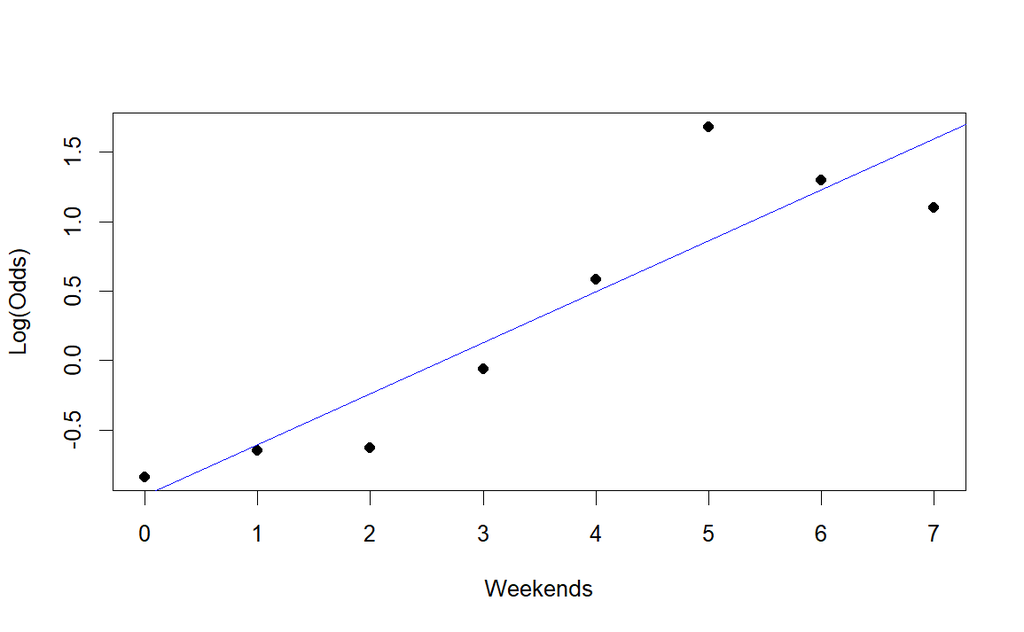

```
Call:
glm(formula = factor(Status) ~ Weeknights, family = binomial(link = "logit"),
    data = hotel_bookings)

Coefficients:
            Estimate Std. Error z value Pr(>|z|)
(Intercept)  1.02668    0.02119   48.46   <2e-16 ***
Weeknights  -0.13710    0.00788  -17.40   <2e-16 ***
---
Signif. codes:  0 ‘***’ 0.001 ‘**’ 0.01 ‘*’ 0.05 ‘.’ 0.1 ‘ ’ 1

(Dispersion parameter for binomial family taken to be 1)

    Null deviance: 45901  on 36284  degrees of freedom
Residual deviance: 45595  on 36283  degrees of freedom
AIC: 45599

Number of Fisher Scoring iterations: 4
```

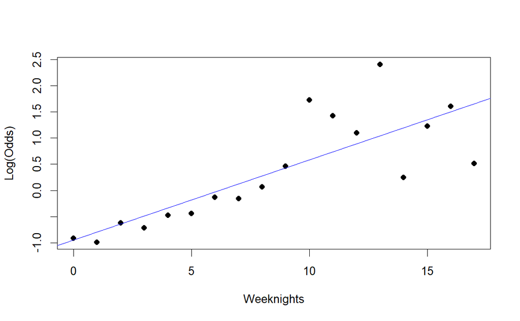

```
Call:
glm(formula = factor(Status) ~ Requests, family = binomial(link = "logit"),
    data = hotel_bookings)

Coefficients:
            Estimate Std. Error z value Pr(>|z|)
(Intercept)  0.27765    0.01392   19.95   <2e-16 ***
Requests     0.84692    0.01826   46.37   <2e-16 ***
---
Signif. codes:  0 ‘***’ 0.001 ‘**’ 0.01 ‘*’ 0.05 ‘.’ 0.1 ‘ ’ 1

(Dispersion parameter for binomial family taken to be 1)

    Null deviance: 45901  on 36284  degrees of freedom
Residual deviance: 43272  on 36283  degrees of freedom
AIC: 43276

Number of Fisher Scoring iterations: 4
```

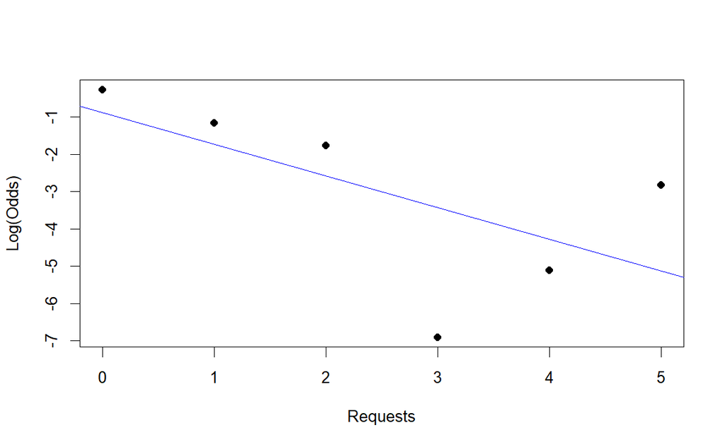

**Categorical Variable Models**

```
Call:
glm(formula = factor(Status) ~ RoomType, family = binomial(link = "logit"),
    data = hotel_bookings)

Coefficients:
                    Estimate Std. Error z value Pr(>|z|)
(Intercept)          0.74206    0.01275  58.187  < 2e-16 ***
RoomTypeRoom_Type 2 -0.03152    0.08188  -0.385  0.70022
RoomTypeRoom_Type 3  0.17423    0.83676   0.208  0.83506
RoomTypeRoom_Type 4 -0.08534    0.02994  -2.850  0.00437 **
RoomTypeRoom_Type 5  0.24396    0.13868   1.759  0.07856 .
RoomTypeRoom_Type 6 -0.42048    0.06642  -6.331 2.44e-10 ***
RoomTypeRoom_Type 7  0.47844    0.19010   2.517  0.01184 *
---
Signif. codes:  0 ‘***’ 0.001 ‘**’ 0.01 ‘*’ 0.05 ‘.’ 0.1 ‘ ’ 1

(Dispersion parameter for binomial family taken to be 1)

    Null deviance: 45901  on 36284  degrees of freedom
Residual deviance: 45845  on 36278  degrees of freedom
AIC: 45859

Number of Fisher Scoring iterations: 4


Call:
glm(formula = factor(Status) ~ Parking, family = binomial(link = "logit"),
    data = hotel_bookings)

Coefficients:
            Estimate Std. Error z value Pr(>|z|)
(Intercept)  0.68616    0.01130   60.72   <2e-16 ***
Parking      1.49535    0.09944   15.04   <2e-16 ***
---
Signif. codes:  0 ‘***’ 0.001 ‘**’ 0.01 ‘*’ 0.05 ‘.’ 0.1 ‘ ’ 1

(Dispersion parameter for binomial family taken to be 1)

    Null deviance: 45901  on 36284  degrees of freedom
Residual deviance: 45574  on 36283  degrees of freedom
```

[output cut: 103 more lines]

```

Coefficients:
            Estimate Std. Error z value Pr(>|z|)
(Intercept)  0.73489    0.01166  63.033  < 2e-16 ***
HasChildren -0.20943    0.04148  -5.049 4.45e-07 ***
---
Signif. codes:  0 ‘***’ 0.001 ‘**’ 0.01 ‘*’ 0.05 ‘.’ 0.1 ‘ ’ 1

(Dispersion parameter for binomial family taken to be 1)

    Null deviance: 45901  on 36284  degrees of freedom
Residual deviance: 45876  on 36283  degrees of freedom
AIC: 45880

Number of Fisher Scoring iterations: 4
```

**Combined Variable and Final Models**

```
Start:  AIC=45902.98
factor(Status) ~ 1

                   Df Deviance   AIC
+ LeadTime          1    38894 38898
+ HasRequests       1    43686 43690
+ factor(Month)    11    44226 44250
+ factor(Market)    4    44879 44889
+ AvgPrice          1    45167 45171
+ StayLength        1    45524 45528
+ factor(Parking)   1    45574 45578
+ GroupSize         1    45612 45616
+ factor(Meal)      3    45634 45642
+ factor(RoomType)  6    45845 45859
<none>                   45901 45903

Step:  AIC=38898.17
factor(Status) ~ LeadTime

                   Df Deviance   AIC
+ HasRequests       1    37078 37084
+ factor(Market)    4    37267 37279
+ AvgPrice          1    37491 37497
+ factor(Month)    11    37671 37697
+ factor(RoomType)  6    38630 38646
+ GroupSize         1    38661 38667
+ factor(Parking)   1    38697 38703
+ factor(Meal)      3    38750 38760
+ StayLength        1    38812 38818
<none>                   38894 38898

Step:  AIC=37084.44
factor(Status) ~ LeadTime + HasRequests

                   Df Deviance   AIC
+ factor(Market)    4    33257 33271
+ AvgPrice          1    35004 35012
+ factor(Month)    11    35794 35822
+ GroupSize         1    36436 36444
+ factor(RoomType)  6    36591 36609
```

[output cut: 127 more lines]

```
---
Signif. codes:  0 ‘***’ 0.001 ‘**’ 0.01 ‘*’ 0.05 ‘.’ 0.1 ‘ ’ 1
Analysis of Deviance Table (Type II tests)

Response: factor(Status)
               LR Chisq Df Pr(>Chisq)
LeadTime         7937.8  1  < 2.2e-16 ***
factor(Market)   2553.0  4  < 2.2e-16 ***
HasRequests      4287.6  1  < 2.2e-16 ***
factor(Month)    1097.4 11  < 2.2e-16 ***
AvgPrice          945.0  1  < 2.2e-16 ***
StayLength         65.1  1  7.202e-16 ***
---
Signif. codes:  0 ‘***’ 0.001 ‘**’ 0.01 ‘*’ 0.05 ‘.’ 0.1 ‘ ’ 1
[1] 31109.38
```

**Cross Validation**

```
Call:
glm(formula = factor(Status) ~ LeadTime + HasRequests + factor(Market) +
    factor(Month) + AvgPrice + factor(Parking) + factor(RoomType) +
    StayLength + factor(Meal) + StayLength, family = binomial(link = "logit"),
    data = train_data)

Coefficients:
                              Estimate Std. Error z value Pr(>|z|)
(Intercept)                  4.900e+00  4.085e-01  11.992  < 2e-16 ***
LeadTime                    -1.680e-02  3.180e-04 -52.838  < 2e-16 ***
HasRequests                  1.983e+00  4.776e-02  41.524  < 2e-16 ***
factor(Market)Complementary  1.306e+01  1.466e+02   0.089 0.928987
factor(Market)Corporate      1.068e+00  3.162e-01   3.378 0.000730 ***
factor(Market)Offline        1.929e+00  3.032e-01   6.363 1.98e-10 ***
factor(Market)Online         1.373e-02  2.993e-01   0.046 0.963403
factor(Month)Feb            -2.736e+00  2.815e-01  -9.719  < 2e-16 ***
factor(Month)Mar            -2.390e+00  2.778e-01  -8.604  < 2e-16 ***
factor(Month)Apr            -2.165e+00  2.759e-01  -7.845 4.34e-15 ***
factor(Month)May            -1.736e+00  2.784e-01  -6.238 4.42e-10 ***
factor(Month)Jun            -1.977e+00  2.768e-01  -7.140 9.35e-13 ***
factor(Month)Jul            -1.836e+00  2.775e-01  -6.616 3.70e-11 ***
factor(Month)Aug            -1.791e+00  2.760e-01  -6.489 8.64e-11 ***
factor(Month)Sep            -1.512e+00  2.762e-01  -5.477 4.32e-08 ***
factor(Month)Oct            -1.838e+00  2.742e-01  -6.705 2.02e-11 ***
factor(Month)Nov            -2.278e+00  2.779e-01  -8.199 2.42e-16 ***
factor(Month)Dec            -5.518e-01  2.850e-01  -1.937 0.052800 .
AvgPrice                    -1.881e-02  9.111e-04 -20.644  < 2e-16 ***
factor(Parking)1             1.658e+00  1.734e-01   9.559  < 2e-16 ***
factor(RoomType)Room_Type 2  2.736e-01  1.518e-01   1.802 0.071475 .
factor(RoomType)Room_Type 3  9.129e-02  2.702e+00   0.034 0.973045
factor(RoomType)Room_Type 4  2.893e-01  6.079e-02   4.759 1.95e-06 ***
factor(RoomType)Room_Type 5  9.154e-01  2.512e-01   3.644 0.000268 ***
factor(RoomType)Room_Type 6  6.885e-01  1.408e-01   4.891 1.00e-06 ***
factor(RoomType)Room_Type 7  1.289e+00  3.483e-01   3.701 0.000214 ***
StayLength                  -7.436e-02  1.156e-02  -6.430 1.27e-10 ***
factor(Meal)Meal Plan 2     -2.046e-01  7.666e-02  -2.669 0.007609 **
factor(Meal)Meal Plan 3     -5.110e+00  2.404e+03  -0.002 0.998304
factor(Meal)Not Selected    -3.304e-01  6.312e-02  -5.236 1.65e-07 ***
---
Signif. codes:  0 ‘***’ 0.001 ‘**’ 0.01 ‘*’ 0.05 ‘.’ 0.1 ‘ ’ 1
```

[output cut: 16 more lines]

```

                 Df Deviance Resid. Df Resid. Dev  Pr(>Chi)
NULL                             18141      22912
LeadTime          1   3628.0     18140      19284 < 2.2e-16 ***
HasRequests       1    830.8     18139      18453 < 2.2e-16 ***
factor(Market)    4   1871.1     18135      16582 < 2.2e-16 ***
factor(Month)    11    549.5     18124      16032 < 2.2e-16 ***
AvgPrice          1    433.6     18123      15599 < 2.2e-16 ***
factor(Parking)   1    123.7     18122      15475 < 2.2e-16 ***
factor(RoomType)  6     65.3     18116      15410 3.720e-12 ***
StayLength        1     34.5     18115      15375 4.240e-09 ***
factor(Meal)      3     33.8     18112      15341 2.201e-07 ***
---
Signif. codes:  0 ‘***’ 0.001 ‘**’ 0.01 ‘*’ 0.05 ‘.’ 0.1 ‘ ’ 1
[1] -0.002450414
```

```
Call:
glm(formula = factor(Status) ~ LeadTime + HasRequests + factor(Market) +
    factor(Month) + AvgPrice + factor(Parking) + factor(RoomType) +
    StayLength + factor(Meal) + StayLength, family = binomial(link = "logit"),
    data = train_data)

Coefficients:
                              Estimate Std. Error z value Pr(>|z|)
(Intercept)                  5.003e+00  4.070e-01  12.291  < 2e-16 ***
LeadTime                    -1.652e-02  3.158e-04 -52.298  < 2e-16 ***
HasRequests                  2.042e+00  4.813e-02  42.434  < 2e-16 ***
factor(Market)Complementary  1.982e+01  2.798e+02   0.071  0.94352
factor(Market)Corporate      8.486e-01  3.137e-01   2.705  0.00683 **
factor(Market)Offline        1.736e+00  3.004e-01   5.777 7.60e-09 ***
factor(Market)Online        -1.298e-01  2.969e-01  -0.437  0.66188
factor(Month)Feb            -2.522e+00  2.823e-01  -8.932  < 2e-16 ***
factor(Month)Mar            -2.168e+00  2.782e-01  -7.792 6.62e-15 ***
factor(Month)Apr            -2.020e+00  2.766e-01  -7.304 2.79e-13 ***
factor(Month)May            -1.663e+00  2.789e-01  -5.963 2.47e-09 ***
factor(Month)Jun            -1.923e+00  2.772e-01  -6.935 4.07e-12 ***
factor(Month)Jul            -1.793e+00  2.775e-01  -6.461 1.04e-10 ***
factor(Month)Aug            -1.700e+00  2.765e-01  -6.147 7.87e-10 ***
factor(Month)Sep            -1.493e+00  2.767e-01  -5.398 6.73e-08 ***
factor(Month)Oct            -1.712e+00  2.747e-01  -6.232 4.62e-10 ***
factor(Month)Nov            -2.143e+00  2.785e-01  -7.698 1.39e-14 ***
factor(Month)Dec            -2.685e-01  2.866e-01  -0.937  0.34890
AvgPrice                    -1.933e-02  9.002e-04 -21.474  < 2e-16 ***
factor(Parking)1             1.678e+00  1.669e-01  10.052  < 2e-16 ***
factor(RoomType)Room_Type 2  1.532e-01  1.493e-01   1.026  0.30481
factor(RoomType)Room_Type 3  8.411e-02  2.674e+00   0.031  0.97491
factor(RoomType)Room_Type 4  2.879e-01  6.147e-02   4.685 2.80e-06 ***
factor(RoomType)Room_Type 5  1.008e+00  2.417e-01   4.171 3.04e-05 ***
factor(RoomType)Room_Type 6  7.543e-01  1.389e-01   5.431 5.59e-08 ***
factor(RoomType)Room_Type 7  1.510e+00  3.751e-01   4.025 5.70e-05 ***
StayLength                  -8.705e-02  1.157e-02  -7.521 5.44e-14 ***
factor(Meal)Meal Plan 2     -1.803e-01  7.669e-02  -2.351  0.01875 *
factor(Meal)Meal Plan 3     -1.222e+01  2.007e+02  -0.061  0.95146
factor(Meal)Not Selected    -3.740e-01  6.317e-02  -5.921 3.20e-09 ***
---
Signif. codes:  0 ‘***’ 0.001 ‘**’ 0.01 ‘*’ 0.05 ‘.’ 0.1 ‘ ’ 1
```

[output cut: 16 more lines]

```

                 Df Deviance Resid. Df Resid. Dev  Pr(>Chi)
NULL                             18141      22912
LeadTime          1   3565.1     18140      19347 < 2.2e-16 ***
HasRequests       1    934.6     18139      18412 < 2.2e-16 ***
factor(Market)    4   1857.6     18135      16555 < 2.2e-16 ***
factor(Month)    11    577.6     18124      15977 < 2.2e-16 ***
AvgPrice          1    453.0     18123      15524 < 2.2e-16 ***
factor(Parking)   1    134.0     18122      15390 < 2.2e-16 ***
factor(RoomType)  6     70.7     18116      15319 2.969e-13 ***
StayLength        1     48.0     18115      15271 4.195e-12 ***
factor(Meal)      3     41.8     18112      15230 4.416e-09 ***
---
Signif. codes:  0 ‘***’ 0.001 ‘**’ 0.01 ‘*’ 0.05 ‘.’ 0.1 ‘ ’ 1
[1] 0.01192023
```